# Eigenvalues / EigenVectors, Covariance, Correlation

1. Introduction
2. Eigenvalues and eigenvectors
3. Covariance
4. Correlation
5. Application with the diabetes dataset
6. Conclusion

# Introduction

The goal of this netbook is to understand the definition of eigenvalue/vector, variance/covariance, the correlation.  
We will make some functions to calculate this parameters and compare them with numpy/pandas functions

```python
# Import numpy library
import numpy as np
```

# Eigenvalues and eigenvectors

Example of eigenvalues and eigenvectors, A is a matrix of (nxn): n=2

```python
A=np.array([[7,3],[3,-1]])
```

The identity matrix (nxn)

```python
I=np.identity(len(A))
I
```

```
array([[1., 0.],
       [0., 1.]])
```

#### Eigenvalues and eigenvectors: Numpy function

```python
lambdas,vecs=np.linalg.eig(A)
```

### Eigenvalues

The eigenvalues of a matrix A is defined as the lambda values that verify the below equation:  
***det(A − λI)=0***

```python
lambdas
```

```
array([ 8., -2.])
```

##### The det(A)

```python
np.linalg.det(A)
```

```
-15.999999999999998
```

##### The first eigenvalue

```python
np.linalg.det(A-8*I)
```

```
0.0
```

##### The second eigenvalue

```python
np.linalg.det(A+2*I)
```

```
0.0
```

### Eigenverctors

For each eigenvalue **λ**, the eigenvector **v** is defined by the below equation

$ {\displaystyle \left(A-\lambda I\right)\mathbf {v} =\mathbf {0} ,} $

```python
vecs.T
```

```
array([[ 0.9486833 ,  0.31622777],
       [-0.31622777,  0.9486833 ]])
```

##### The fist eignevector

```python
(A-8*I).dot(vecs.T[0])
```

```
array([ 0.00000000e+00, -2.22044605e-16])
```

the product is practically **0**

##### The second eignevector

```python
(A+2*I).dot(vecs.T[1])
```

```
array([-3.88578059e-16, -5.55111512e-17])
```

the product is practically **0**

For more details, please see the wikipedia page:  
https://en.wikipedia.org/wiki/Eigenvalues_and_eigenvectors

# Covariance

The covariance of vectors ***X*** and ***Y*** is defined by the below equation:

$ \operatorname {Cov}(X,Y)\equiv \operatorname {E}[(X-\operatorname {E}[X])\,(Y-\operatorname {E}[Y])] $

### Covariance of two vectors

```python
def cov(x,y):
    return ((x-x.mean())*(y-y.mean())).mean()
```

We use seed to find the same random output each time

***X*** vector

```python
np.random.seed(1)
X=np.random.uniform(-1,1,5)
X
```

```
array([-0.16595599,  0.44064899, -0.99977125, -0.39533485, -0.70648822])
```

***Y*** vector

```python
np.random.seed(2)
Y=np.random.uniform(-1,1,5)
Y
```

```
array([-0.1280102 , -0.94814754,  0.09932496, -0.12935521, -0.1592644 ])
```

##### The covariance of X,Y

```python
cov(X,Y)
```

```
-0.15891454248114759
```

##### Comparaison with numpy covariance function

```python
np.cov(X,Y)[0][1]
```

```
-0.19864317810143445
```

The value calculated by numpy function is different, because the default numpy function use a bias correction

##### The covariance funciton of two vectors with the bias correction

```python
def cov2(x,y,bias_correction=True):
    n=len(x)
    if bias_correction:
        return ((x-x.mean())*(y-y.mean())).mean()*n/(n-1)
    else:
        return ((x-x.mean())*(y-y.mean())).mean()
```

##### X,Y covariance with bias correction: same as numpy function

```python
cov2(X,Y)
```

```
-0.19864317810143448
```

##### X,Y covariance without bias correction

```python
cov2(X,Y,bias_correction=False)
```

```
-0.15891454248114759
```

### The covariance of a matrix (nxm)

Wikipedia definition: For matrix ***M***

$ { M}={\begin{pmatrix}X_{1}\\\vdots \\X_{p}\end{pmatrix}} $

The covariance is defined as:

$ \operatorname {Cov}({M})={\begin{pmatrix}\operatorname {Var}(X_{1})&\operatorname {Cov}(X_{{1}},X_{{2}})&\cdots &\operatorname {Cov}(X_{{1}},X_{{p}})\\\operatorname {Cov}(X_{{2}},X_{{1}})&\ddots &\cdots &\vdots \\\vdots &\vdots &\ddots &\vdots \\\operatorname {Cov}(X_{{p}},X_{{1}})&\cdots &\cdots &\operatorname {Var}(X_{p})\end{pmatrix}}={\begin{pmatrix}\sigma _{{x_{1}}}^{2}&\sigma _{{x_{{1}}x_{{2}}}}&\cdots &\sigma _{{x_{{1}}x_{{p}}}}\\\sigma _{{x_{{2}}x_{{1}}}}&\ddots &\cdots &\vdots \\\vdots &\vdots &\ddots &\vdots \\\sigma _{{x_{{p}}x_{{1}}}}&\cdots &\cdots &\sigma _{{x_{p}}}^{2}\end{pmatrix}} $

With Var(Xi)=Cov(Xi,Xi)

##### The covariance function of a matrix M

```python
def CovM(M,bias_correction=True):
    cov_out=np.zeros((M.shape[0],M.shape[0]))
    for i,x1 in enumerate(M):
        for j,x2 in enumerate(M):
            cov_out[i,j]=cov2(x1,x2,bias_correction=bias_correction)
    return cov_out
```

##### M matrix

We use seed to find the same random output each time

```python
np.random.seed(3)
M=np.random.uniform(-10,10,(3,3))
M
```

```
array([[ 1.01595805,  4.16295645, -4.18190522],
       [ 0.2165521 ,  7.85893909,  7.92586178],
       [-7.48829379, -5.85514244, -8.97065593]])
```

##### The covariance of ***M*** With our funcition

```python
CovM(M)
```

```
array([[17.75968298, -2.7633031 ,  6.4738616 ],
       [-2.7633031 , 19.64066885,  0.14078121],
       [ 6.4738616 ,  0.14078121,  2.42850087]])
```

##### Comparaison with numpy funciton

```python
np.cov(M)
```

```
array([[17.75968298, -2.7633031 ,  6.4738616 ],
       [-2.7633031 , 19.64066885,  0.14078121],
       [ 6.4738616 ,  0.14078121,  2.42850087]])
```

We find the same result: fine 👌

For more information, please see the wikipedia pages below:  
https://fr.wikipedia.org/wiki/Covariance  
https://en.wikipedia.org/wiki/Covariance_matrix

# Correlation

Wikipedia definition:

The population correlation coefficient $ {\displaystyle \rho _{X,Y}}$ between two random variables $X$ and $Y$ with expected values $ \mu _{X} $ and $\sigma _{X}$ and $ \sigma_Y $ is defined as:

$ {\displaystyle \rho _{X,Y}=\operatorname {corr} (X,Y)={\operatorname {cov} (X,Y) \over \sigma _{X}\sigma _{Y}}={\operatorname {E} [(X-\mu _{X})(Y-\mu _{Y})] \over \sigma _{X}\sigma _{Y}},\quad {\text{if}}\ \sigma _{X}\sigma _{Y}>0.}$

The Pearson correlation is defined only if both standard deviations are finite and positive. An alternative formula purely in terms of moments is:

$ {\displaystyle \rho _{X,Y}={\operatorname {E} (XY)-\operatorname {E} (X)\operatorname {E} (Y) \over {\sqrt {\operatorname {E} (X^{2})-\operatorname {E} (X)^{2}}}\cdot {\sqrt {\operatorname {E} (Y^{2})-\operatorname {E} (Y)^{2}}}}} $

E(X)=Average(X)

**unlike the covariance, the correlation coefficient is in the range [-1,1]**

### The correlation funciton of two vectros

```python
def corr(x,y):
    #return cov2(x,y)/(x.std()*y.std())
    N=(x*y).mean()-x.mean()*y.mean()
    D=np.sqrt((x**2).mean()-x.mean()**2)
    D=D*np.sqrt((y**2).mean()-y.mean()**2)
    return N/D
```

Reminder of X,Y vectors already defined

```python
X,Y
```

```
(array([-0.16595599,  0.44064899, -0.99977125, -0.39533485, -0.70648822]),
 array([-0.1280102 , -0.94814754,  0.09932496, -0.12935521, -0.1592644 ]))
```

##### The correlation of X, Y: calculation by the defined function

```python
corr(X,Y)
```

```
-0.8982972930960346
```

##### Comparaison with numpy function

```python
np.corrcoef(X, Y)[0,1]
```

```
-0.8982972930960343
```

We find the same result

### The correlation of a matrix

```python
def corrM(M):
    corr_out=np.zeros((M.shape[0],M.shape[0]))
    for i,x1 in enumerate(M):
        for j,x2 in enumerate(M):
            corr_out[i,j]=corr(x1,x2)
    return corr_out
```

Reminder of the M matrix

```python
M
```

```
array([[ 1.01595805,  4.16295645, -4.18190522],
       [ 0.2165521 ,  7.85893909,  7.92586178],
       [-7.48829379, -5.85514244, -8.97065593]])
```

##### M correlation with the local function

```python
corrM(M)
```

```
array([[ 1.        , -0.14795607,  0.98577245],
       [-0.14795607,  1.        ,  0.02038438],
       [ 0.98577245,  0.02038438,  1.        ]])
```

##### M correlation with numpy function

```python
np.corrcoef(M)
```

```
array([[ 1.        , -0.14795607,  0.98577245],
       [-0.14795607,  1.        ,  0.02038438],
       [ 0.98577245,  0.02038438,  1.        ]])
```

We found the same value

For more information, please see the wikipedia pages below:  
https://en.wikipedia.org/wiki/Correlation  
https://en.wikipedia.org/wiki/Correlation

# Application with the diabetes dataset

### The dataset

For more information about this dataset, please see the project [Linear Logistic Regression with NumPy pure code and a comparison wit Sklearn model](https://bouz1.github.io/fils/NumpyLR.html), or the official link https://scikit-learn.org/stable/datasets/toy_dataset.html

##### Import the dataset

```python
from sklearn import datasets
X,Y=datasets.load_diabetes(return_X_y=True)
```

##### Organize data in Pandas DataFrame

```python
import pandas as pd
```

```python
inp=['x'+str(i) for i in range(X.shape[1])]
inp+['y']
```

```
['x0', 'x1', 'x2', 'x3', 'x4', 'x5', 'x6', 'x7', 'x8', 'x9', 'y']
```

```python
['x0', 'x1', 'x2', 'x3', 'x4', 'x5', 'x6', 'x7', 'x8', 'x9', 'y']
df=pd.concat([pd.DataFrame(X,columns=inp),pd.DataFrame(Y,columns=['y'])],axis=1)
df.head(3)
```

|  | x0 | x1 | x2 | x3 | x4 | x5 | x6 | x7 | x8 | x9 | y |
| --- | --- | --- | --- | --- | --- | --- | --- | --- | --- | --- | --- |
| 0 | 0.038076 | 0.050680 | 0.061696 | 0.021872 | -0.044223 | -0.034821 | -0.043401 | -0.002592 | 0.019907 | -0.017646 | 151.0 |
| 1 | -0.001882 | -0.044642 | -0.051474 | -0.026328 | -0.008449 | -0.019163 | 0.074412 | -0.039493 | -0.068332 | -0.092204 | 75.0 |
| 2 | 0.085299 | 0.050680 | 0.044451 | -0.005670 | -0.045599 | -0.034194 | -0.032356 | -0.002592 | 0.002861 | -0.025930 | 141.0 |

### The covariance

##### The covariance with panda funcition:

```python
df.cov()
```

|  | x0 | x1 | x2 | x3 | x4 | x5 | x6 | x7 | x8 | x9 | y |
| --- | --- | --- | --- | --- | --- | --- | --- | --- | --- | --- | --- |
| x0 | 0.002268 | 0.000394 | 0.000420 | 0.000761 | 0.000590 | 0.000497 | -0.000170 | 0.000462 | 0.000614 | 0.000684 | 0.689758 |
| x1 | 0.000394 | 0.002268 | 0.000200 | 0.000547 | 0.000080 | 0.000323 | -0.000860 | 0.000753 | 0.000340 | 0.000472 | 0.158085 |
| x2 | 0.000420 | 0.000200 | 0.002268 | 0.000897 | 0.000566 | 0.000592 | -0.000832 | 0.000938 | 0.001012 | 0.000881 | 2.152914 |
| x3 | 0.000761 | 0.000547 | 0.000897 | 0.002268 | 0.000550 | 0.000421 | -0.000405 | 0.000584 | 0.000892 | 0.000885 | 1.620722 |
| x4 | 0.000590 | 0.000080 | 0.000566 | 0.000550 | 0.002268 | 0.002033 | 0.000117 | 0.001229 | 0.001169 | 0.000739 | 0.778355 |
| x5 | 0.000497 | 0.000323 | 0.000592 | 0.000421 | 0.002033 | 0.002268 | -0.000445 | 0.001496 | 0.000722 | 0.000659 | 0.638967 |
| x6 | -0.000170 | -0.000860 | -0.000832 | -0.000405 | 0.000117 | -0.000445 | 0.002268 | -0.001675 | -0.000904 | -0.000621 | -1.449309 |
| x7 | 0.000462 | 0.000753 | 0.000938 | 0.000584 | 0.001229 | 0.001496 | -0.001675 | 0.002268 | 0.001401 | 0.000946 | 1.580234 |
| x8 | 0.000614 | 0.000340 | 0.001012 | 0.000892 | 0.001169 | 0.000722 | -0.000904 | 0.001401 | 0.002268 | 0.001054 | 2.077409 |
| x9 | 0.000684 | 0.000472 | 0.000881 | 0.000885 | 0.000739 | 0.000659 | -0.000621 | 0.000946 | 0.001054 | 0.002268 | 1.404133 |
| y | 0.689758 | 0.158085 | 2.152914 | 1.620722 | 0.778355 | 0.638967 | -1.449309 | 1.580234 | 2.077409 | 1.404133 | 5943.331348 |

##### The covariance with our function

For more visibility: Convert the result to a dataframe

```python
pd.DataFrame(CovM(df.values.T))
```

|  | 0 | 1 | 2 | 3 | 4 | 5 | 6 | 7 | 8 | 9 | 10 |
| --- | --- | --- | --- | --- | --- | --- | --- | --- | --- | --- | --- |
| 0 | 0.002268 | 0.000394 | 0.000420 | 0.000761 | 0.000590 | 0.000497 | -0.000170 | 0.000462 | 0.000614 | 0.000684 | 0.689758 |
| 1 | 0.000394 | 0.002268 | 0.000200 | 0.000547 | 0.000080 | 0.000323 | -0.000860 | 0.000753 | 0.000340 | 0.000472 | 0.158085 |
| 2 | 0.000420 | 0.000200 | 0.002268 | 0.000897 | 0.000566 | 0.000592 | -0.000832 | 0.000938 | 0.001012 | 0.000881 | 2.152914 |
| 3 | 0.000761 | 0.000547 | 0.000897 | 0.002268 | 0.000550 | 0.000421 | -0.000405 | 0.000584 | 0.000892 | 0.000885 | 1.620722 |
| 4 | 0.000590 | 0.000080 | 0.000566 | 0.000550 | 0.002268 | 0.002033 | 0.000117 | 0.001229 | 0.001169 | 0.000739 | 0.778355 |
| 5 | 0.000497 | 0.000323 | 0.000592 | 0.000421 | 0.002033 | 0.002268 | -0.000445 | 0.001496 | 0.000722 | 0.000659 | 0.638967 |
| 6 | -0.000170 | -0.000860 | -0.000832 | -0.000405 | 0.000117 | -0.000445 | 0.002268 | -0.001675 | -0.000904 | -0.000621 | -1.449309 |
| 7 | 0.000462 | 0.000753 | 0.000938 | 0.000584 | 0.001229 | 0.001496 | -0.001675 | 0.002268 | 0.001401 | 0.000946 | 1.580234 |
| 8 | 0.000614 | 0.000340 | 0.001012 | 0.000892 | 0.001169 | 0.000722 | -0.000904 | 0.001401 | 0.002268 | 0.001054 | 2.077409 |
| 9 | 0.000684 | 0.000472 | 0.000881 | 0.000885 | 0.000739 | 0.000659 | -0.000621 | 0.000946 | 0.001054 | 0.002268 | 1.404133 |
| 10 | 0.689758 | 0.158085 | 2.152914 | 1.620722 | 0.778355 | 0.638967 | -1.449309 | 1.580234 | 2.077409 | 1.404133 | 5943.331348 |

We find the same result

### The correlation

##### The correlation with panda funcition:

```python
df.corr()
```

|  | x0 | x1 | x2 | x3 | x4 | x5 | x6 | x7 | x8 | x9 | y |
| --- | --- | --- | --- | --- | --- | --- | --- | --- | --- | --- | --- |
| x0 | 1.000000 | 0.173737 | 0.185085 | 0.335428 | 0.260061 | 0.219243 | -0.075181 | 0.203841 | 0.270774 | 0.301731 | 0.187889 |
| x1 | 0.173737 | 1.000000 | 0.088161 | 0.241010 | 0.035277 | 0.142637 | -0.379090 | 0.332115 | 0.149916 | 0.208133 | 0.043062 |
| x2 | 0.185085 | 0.088161 | 1.000000 | 0.395411 | 0.249777 | 0.261170 | -0.366811 | 0.413807 | 0.446157 | 0.388680 | 0.586450 |
| x3 | 0.335428 | 0.241010 | 0.395411 | 1.000000 | 0.242464 | 0.185548 | -0.178762 | 0.257650 | 0.393480 | 0.390430 | 0.441482 |
| x4 | 0.260061 | 0.035277 | 0.249777 | 0.242464 | 1.000000 | 0.896663 | 0.051519 | 0.542207 | 0.515503 | 0.325717 | 0.212022 |
| x5 | 0.219243 | 0.142637 | 0.261170 | 0.185548 | 0.896663 | 1.000000 | -0.196455 | 0.659817 | 0.318357 | 0.290600 | 0.174054 |
| x6 | -0.075181 | -0.379090 | -0.366811 | -0.178762 | 0.051519 | -0.196455 | 1.000000 | -0.738493 | -0.398577 | -0.273697 | -0.394789 |
| x7 | 0.203841 | 0.332115 | 0.413807 | 0.257650 | 0.542207 | 0.659817 | -0.738493 | 1.000000 | 0.617859 | 0.417212 | 0.430453 |
| x8 | 0.270774 | 0.149916 | 0.446157 | 0.393480 | 0.515503 | 0.318357 | -0.398577 | 0.617859 | 1.000000 | 0.464669 | 0.565883 |
| x9 | 0.301731 | 0.208133 | 0.388680 | 0.390430 | 0.325717 | 0.290600 | -0.273697 | 0.417212 | 0.464669 | 1.000000 | 0.382483 |
| y | 0.187889 | 0.043062 | 0.586450 | 0.441482 | 0.212022 | 0.174054 | -0.394789 | 0.430453 | 0.565883 | 0.382483 | 1.000000 |

##### The correlation with our function

For more visibility: Convert the result to a dataframe

```python
pd.DataFrame(corrM(df.values.T))
```

|  | 0 | 1 | 2 | 3 | 4 | 5 | 6 | 7 | 8 | 9 | 10 |
| --- | --- | --- | --- | --- | --- | --- | --- | --- | --- | --- | --- |
| 0 | 1.000000 | 0.173737 | 0.185085 | 0.335428 | 0.260061 | 0.219243 | -0.075181 | 0.203841 | 0.270774 | 0.301731 | 0.187889 |
| 1 | 0.173737 | 1.000000 | 0.088161 | 0.241010 | 0.035277 | 0.142637 | -0.379090 | 0.332115 | 0.149916 | 0.208133 | 0.043062 |
| 2 | 0.185085 | 0.088161 | 1.000000 | 0.395411 | 0.249777 | 0.261170 | -0.366811 | 0.413807 | 0.446157 | 0.388680 | 0.586450 |
| 3 | 0.335428 | 0.241010 | 0.395411 | 1.000000 | 0.242464 | 0.185548 | -0.178762 | 0.257650 | 0.393480 | 0.390430 | 0.441482 |
| 4 | 0.260061 | 0.035277 | 0.249777 | 0.242464 | 1.000000 | 0.896663 | 0.051519 | 0.542207 | 0.515503 | 0.325717 | 0.212022 |
| 5 | 0.219243 | 0.142637 | 0.261170 | 0.185548 | 0.896663 | 1.000000 | -0.196455 | 0.659817 | 0.318357 | 0.290600 | 0.174054 |
| 6 | -0.075181 | -0.379090 | -0.366811 | -0.178762 | 0.051519 | -0.196455 | 1.000000 | -0.738493 | -0.398577 | -0.273697 | -0.394789 |
| 7 | 0.203841 | 0.332115 | 0.413807 | 0.257650 | 0.542207 | 0.659817 | -0.738493 | 1.000000 | 0.617859 | 0.417212 | 0.430453 |
| 8 | 0.270774 | 0.149916 | 0.446157 | 0.393480 | 0.515503 | 0.318357 | -0.398577 | 0.617859 | 1.000000 | 0.464669 | 0.565883 |
| 9 | 0.301731 | 0.208133 | 0.388680 | 0.390430 | 0.325717 | 0.290600 | -0.273697 | 0.417212 | 0.464669 | 1.000000 | 0.382483 |
| 10 | 0.187889 | 0.043062 | 0.586450 | 0.441482 | 0.212022 | 0.174054 | -0.394789 | 0.430453 | 0.565883 | 0.382483 | 1.000000 |

We find the same result

### A simple plot of the correlation matrix using Seaborn library

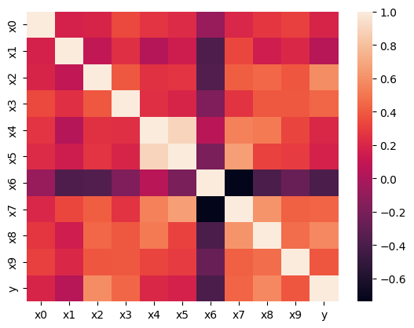

```python
import seaborn as sns

# Compute the correlation matrix
corr = df.corr()

# Draw the heatmap
sns.heatmap(corr)
pass
```

# Conclusion

In this netbook we defined the eigenvalue/vector, variance/covariance, the correlation. In the second hand we compared local function to calculate the parameters with the numpy/pandas functions and we founded the same result each time